# MLProject

In this project, I take the data coming from IoT Devices for build a predictor of the movement type of a subject using a device with an IMU.

## Exploratory Analisys

Get the training and testing datasets from internet:

```r
url <- "https://d396qusza40orc.cloudfront.net/predmachlearn/pml-testing.csv"
download.file(url,"testing.csv",method="curl")
testing <- read.csv("testing.csv")
url <- "https://d396qusza40orc.cloudfront.net/predmachlearn/pml-training.csv"
download.file(url,"training.csv",method="curl")
training <- read.csv("training.csv")
library(dplyr)
```

Remove columns with unnecessary data: these columns related to structure of sampling, including username.

```r
traindata <- training[,-(1:8)]
```

Filter columns with NA or empty spaces:

```r
rowsample <- traindata[1,]
filtercolumns <- is.na(rowsample) | rowsample==""
traindata <- traindata[,!filtercolumns]
```

Verify integrity of rows, these with all values present:

```r
sum(complete.cases(traindata))
```

```
## [1] 19622
```

This number is equal to number of observations in original training data. Verifying data types present in filtered dataset:

```r
table(sapply(traindata,class))
```

```
##
## character   integer   numeric
##         1        25        26
```

The char column is the classe column (outcome). Apply same filtering to testing dataset:

```r
testdata <- testing[,-(1:8)]
testdata <- testdata[,!filtercolumns]
```

Now, we have 51 different covariates. Some are most significant than others. For compress data and have fewer covariates, I apply singular value decomposition for obtain the number of principal vectors needed for explain sufficient variety of the data. Compute Singular Vector Decomposition:

```r
sv <- svd(traindata[,-52])$d
```

Percent of variance explained by a subset of principal vectors:

```r
sapply(1:20,function(i) sum(sv[1:i]^2)/sum(sv^2))
```

```
##  [1] 0.5328219 0.6593745 0.7592899 0.8292029 0.8805231 0.9189444 0.9400256
##  [8] 0.9538158 0.9653649 0.9748885 0.9801659 0.9837602 0.9868071 0.9890436
## [15] 0.9908364 0.9923308 0.9935640 0.9946452 0.9955899 0.9964902
```

We have 88% of the variance explained if we drop the sixth and above principal vectors. Generate first 5 principal vectors of the training dataset.

```r
library(caret)
pcacompute <- preProcess(traindata[,-52],method=c("scale","center","pca"),pcaComp = 5)
pcatraindata <- predict(pcacompute,traindata[,-52])
pcatraindata <- data.frame(pcatraindata,class=traindata$classe)
```

We can plot first two of thee principal vectors for verify some difference between vectors and classes:

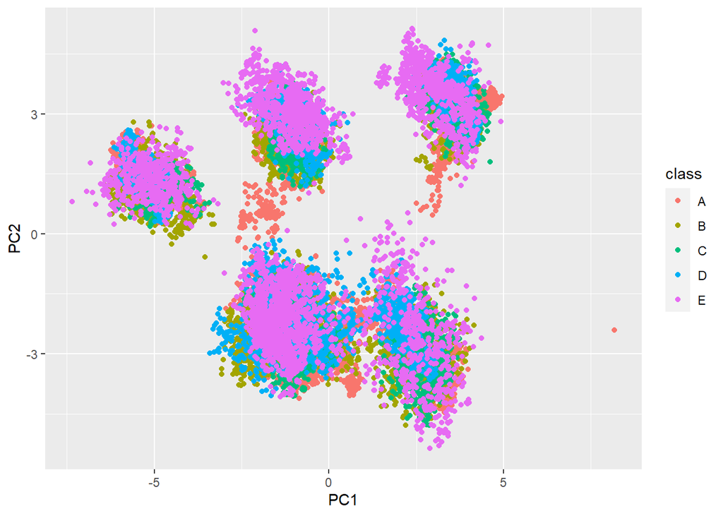

```r
ggplot(aes(x=PC1,y=PC2,col=class),data=pcatraindata)+geom_point()
```

We observe that classes are overlapping, but with some translations on cluster centers. Remember that, only viewing two principal components, we see only 66% of the variation. But another interesting fact, is that we see five blobs of points. Plotting same data, but coloring by user:

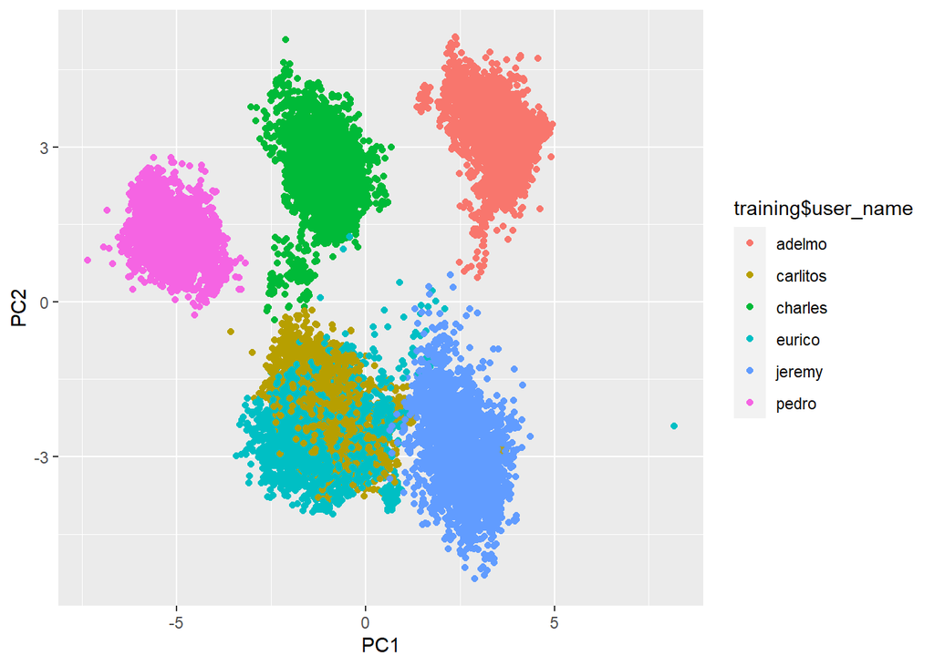

```r
ggplot(aes(x=PC1,y=PC2,col=training$user_name),data=pcatraindata)+geom_point()
```

Because this pattern, inclusion of username covariate in the model may be important.

## Decision Tree

With decision tree method for build a model:

```r
model <- train(class~.,method="rpart",data=pcatraindata)
pr <- predict(model,pcatraindata)
confusionMatrix(as.factor(traindata$classe),pr)
```

```
## Confusion Matrix and Statistics
##
##           Reference
## Prediction    A    B    C    D    E
##          A 4388    0    0    0 1192
##          B 1868    0    0    0 1929
##          C 2301    0    0    0 1121
##          D 1506    0    0  178 1532
##          E 1610    0    0    0 1997
##
## Overall Statistics
##
##                Accuracy : 0.3345
##                  95% CI : (0.3279, 0.3411)
##     No Information Rate : 0.5949
##     P-Value [Acc > NIR] : 1
##
##                   Kappa : 0.1203
##
##  Mcnemar's Test P-Value : NA
##
## Statistics by Class:
##
##                      Class: A Class: B Class: C Class: D Class: E
## Sensitivity            0.3759       NA       NA 1.000000   0.2570
## Specificity            0.8500   0.8065   0.8256 0.843756   0.8641
## Pos Pred Value         0.7864       NA       NA 0.055348   0.5536
## Neg Pred Value         0.4812       NA       NA 1.000000   0.6395
## Prevalence             0.5949   0.0000   0.0000 0.009071   0.3960
## Detection Rate         0.2236   0.0000   0.0000 0.009071   0.1018
## Detection Prevalence   0.2844   0.1935   0.1744 0.163898   0.1838
## Balanced Accuracy      0.6130       NA       NA 0.921878   0.5606
```

The accuracy is very poor, and some classes are never classified.

## Random Forest

```r
cnt <- trainControl(method="cv")
model <- train(class~.,method="rf",data=pcatraindata,trControl=cnt)
model$finalModel
```

```
##
## Call:
##  randomForest(x = x, y = y, mtry = param$mtry)
##                Type of random forest: classification
##                      Number of trees: 500
## No. of variables tried at each split: 2
##
##         OOB estimate of  error rate: 13.06%
## Confusion matrix:
##      A    B    C    D    E class.error
## A 5085   98  177  132   88  0.08870968
## B  235 3165  172  113  112  0.16644720
## C  181  149 2881  148   63  0.15809468
## D  117   63  222 2753   61  0.14396766
## E   93  139   97  103 3175  0.11976712
```

Including username in the training dataset, there is no substantial change in performance, and the Gini decrease for username variable is very low.

```r
pcatraindata$user=training$user_name
cnt <- trainControl(method="cv")
modelnam <- train(class~.,method="rf",data=pcatraindata,trControl=cnt)
modelnam$finalModel
```

```
##
## Call:
##  randomForest(x = x, y = y, mtry = param$mtry)
##                Type of random forest: classification
##                      Number of trees: 500
## No. of variables tried at each split: 6
##
##         OOB estimate of  error rate: 13.08%
## Confusion matrix:
##      A    B    C    D    E class.error
## A 5088   97  182  132   81  0.08817204
## B  227 3184  172  105  109  0.16144324
## C  179  160 2853  165   65  0.16627703
## D  119   47  221 2758   71  0.14241294
## E   95  149   95   96 3172  0.12059884
```

```r
modelnam$finalModel$importance
```

```
##              MeanDecreaseGini
## PC1                3143.31138
## PC2                3014.88937
## PC3                2807.69457
## PC4                2779.55648
## PC5                3185.64659
## usercarlitos        149.58392
## usercharles         164.61952
## usereurico          138.67253
## userjeremy           78.30680
## userpedro            51.41232
```

## Predictions

Using random forest model without username as covariate, calculate predictions on testing data:

```r
pcatestdata <- predict(pcacompute,testdata[,-52])
predict(model,pcatestdata)
```

```
##  [1] B A B A A E D B A A A C B A E E A B B B
## Levels: A B C D E
```

These are the predictions for solve the coursera test. Only one prediction of 20 are failed (5% error rate).